# Prediction of default loans

Bhanuday Birla

10 April 2017

## Objective

The objective of this document is to find out patterns and insights in the Lending Club data of borrowers and also to build a model to accurately predict loan default cases. Now lets load data and see the dimensional size of the data.

```r
setwd('D:\\Data Science\\Loan Prediction')
train=read.csv("loan.csv")
dim(train)
```

```
## [1] 887379     74
```

There are 74 different dimentions and 887379 rows in the data. By looking into data dictionary of the given data, we understand various columns’ meaning here. The data is about the borrowers profile, fico score, grades provided by company and other minute details about credit history of the borrower. On the basis of these details and standard scores like fico score and grades we need to predict whether a loan wil finally end up defaulted or fully paid. Before we build any model, we need to explore and understand data patterns. But before that we need to make response variable in out data set.

```r
library(plyr)
count(train,'loan_status')
```

```
##                                            loan_status   freq
## 1                                          Charged Off  45248
## 2                                              Current 601779
## 3                                              Default   1219
## 4  Does not meet the credit policy. Status:Charged Off    761
## 5   Does not meet the credit policy. Status:Fully Paid   1988
## 6                                           Fully Paid 207723
## 7                                      In Grace Period   6253
## 8                                               Issued   8460
## 9                                    Late (16-30 days)   2357
## 10                                  Late (31-120 days)  11591
```

```r
sum(is.na(train$loan_status))
```

```
## [1] 0
```

There no null values in loan_status variable. We need to drop observations related to ‘Issued’ loan status as it is issued and we are not sure if it is default or not. Also we will make a variable named Default which will have a value of 1 for default cases and 0 otherwise.

```r
train<-train[train['loan_status']!='Issued',]
default <- c("Charged Off",
                    "Default",
                    "Does not meet the credit policy. Status:Charged Off",
                    "Late (16-30 days)",
                    "Late (31-120 days)")
train['Default'] <- ifelse(train$loan_status  %in% default, 1,0)
```

Now lets examine observations with null values and try to fix those or remove those rows in order to retain meaningful data.

```r
NullValues<-colSums(is.na(train))
NullValues
```

```
##                          id                   member_id
##                           0                           0
##                   loan_amnt                 funded_amnt
##                           0                           0
##             funded_amnt_inv                        term
##                           0                           0
##                    int_rate                 installment
##                           0                           0
##                       grade                   sub_grade
##                           0                           0
##                   emp_title                  emp_length
##                           0                           0
##              home_ownership                  annual_inc
##                           0                           4
##         verification_status                     issue_d
##                           0                           0
##                 loan_status                  pymnt_plan
##                           0                           0
##                         url                        desc
##                           0                           0
##                     purpose                       title
##                           0                           0
##                    zip_code                  addr_state
##                           0                           0
##                         dti                 delinq_2yrs
##                           0                          29
##            earliest_cr_line              inq_last_6mths
##                           0                          29
##      mths_since_last_delinq      mths_since_last_record
##                      450296                      743462
##                    open_acc                     pub_rec
##                          29                          29
##                   revol_bal                  revol_util
##                           0                         499
##                   total_acc         initial_list_status
##                          29                           0
##                   out_prncp               out_prncp_inv
##                           0                           0
##                 total_pymnt             total_pymnt_inv
##                           0                           0
```

[output cut: 21 more lines]

```
##                      865549                      865549
##                 open_il_24m          mths_since_rcnt_il
##                      865549                      865903
##                total_bal_il                     il_util
##                      865549                      867235
##                 open_rv_12m                 open_rv_24m
##                      865549                      865549
##                  max_bal_bc                    all_util
##                      865549                      865549
##            total_rev_hi_lim                      inq_fi
##                       70276                      865549
##                 total_cu_tl                inq_last_12m
##                      865549                      865549
##                     Default
##                           0
```

We can see that there are many variables with null values. We will remove the columns with more than 400000 null values(~45% of total values). Such columns are listed below:

```r
RemoveColl<-NullValues[NullValues>400000]
RemoveColl
```

```
##      mths_since_last_delinq      mths_since_last_record
##                      450296                      743462
## mths_since_last_major_derog            annual_inc_joint
##                      659741                      878472
##                   dti_joint                 open_acc_6m
##                      878474                      865549
##                  open_il_6m                 open_il_12m
##                      865549                      865549
##                 open_il_24m          mths_since_rcnt_il
##                      865549                      865903
##                total_bal_il                     il_util
##                      865549                      867235
##                 open_rv_12m                 open_rv_24m
##                      865549                      865549
##                  max_bal_bc                    all_util
##                      865549                      865549
##                      inq_fi                 total_cu_tl
##                      865549                      865549
##                inq_last_12m
##                      865549
```

```r
RemoveColl<-as.vector(names(RemoveColl))
train<-train[,!(names(train) %in% RemoveColl)]
```

There are columns with lesser missing values. We will examine their importance and fill approprite values. Now lets see number of default cases and dependency of grades and interest rates on loan prediction.

```r
count(train,'Default')
```

```
##   Default   freq
## 1       0 817743
## 2       1  61176
```

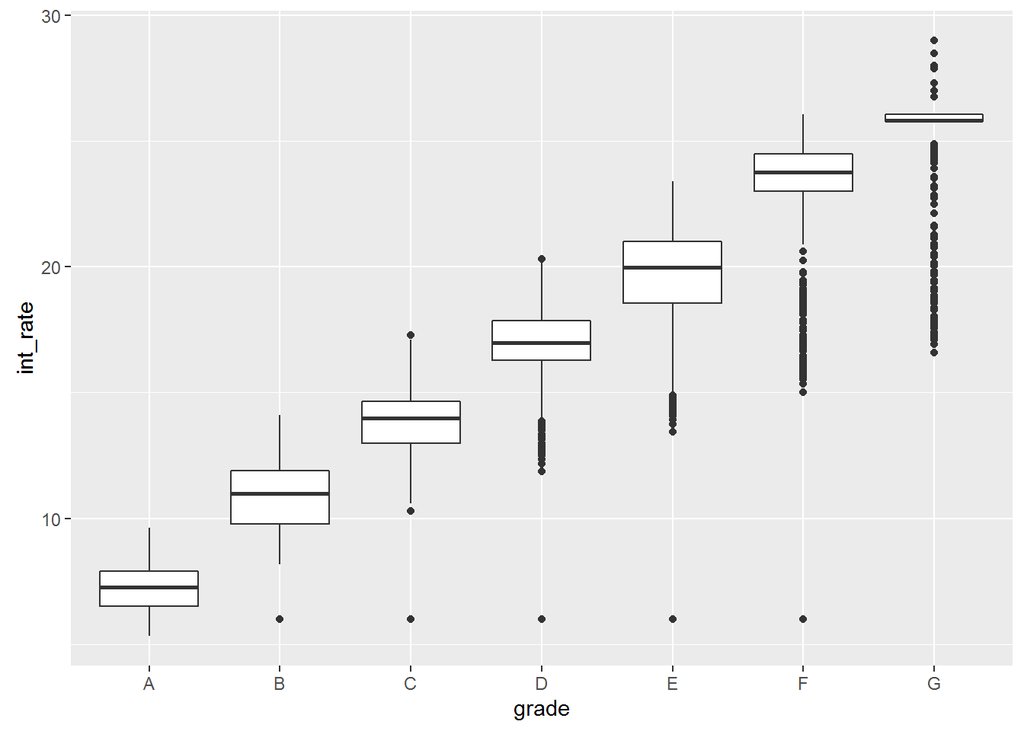

```r
library(ggplot2)
p <- ggplot(train, aes(grade,int_rate))
p + geom_boxplot()
```

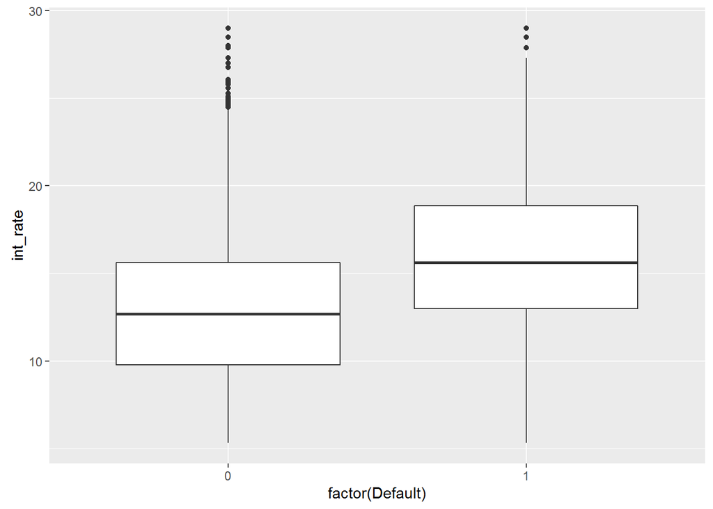

```r
q<-ggplot(train, aes(factor(Default),int_rate))
q + geom_boxplot()
```

Around 7% of cases are default. And risky accounts are charged higher interest rates and having lower grades(like f,g). Lets examine the missing values varibles one by one and fill values. inq_last_6mths open_acc pub_rec revol_util total_acc total_rev_hi_lim acc_now_delinq tot_coll_amt tot_cur_bal

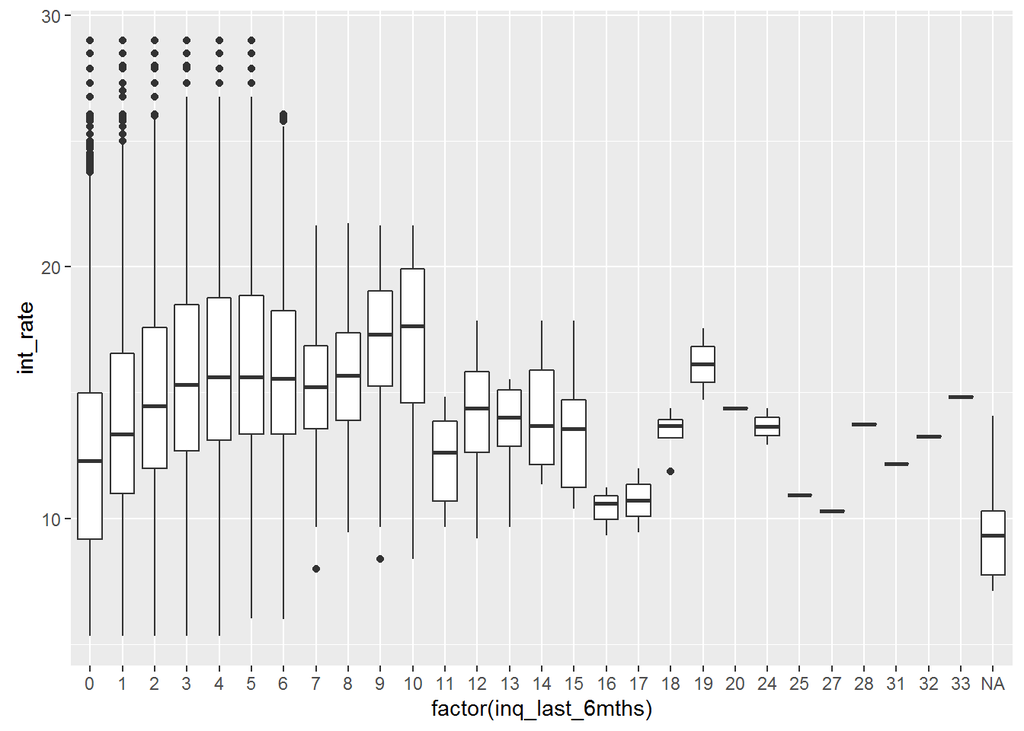

```r
p <- ggplot(train, aes(factor(inq_last_6mths),int_rate))
p + geom_boxplot()
```

```r
chisq.test(table(train[!is.na(train['inq_last_6mths']),c("Default","inq_last_6mths")]))
```

```
##
##  Pearson's Chi-squared test
##
## data:  table(train[!is.na(train["inq_last_6mths"]), c("Default", "inq_last_6mths")])
## X-squared = 6306.7, df = 27, p-value < 2.2e-16
```

```r
chisq.test(table(train[!is.na(train['open_acc']),c("Default","open_acc")]))
```

```
##
##  Pearson's Chi-squared test
##
## data:  table(train[!is.na(train["open_acc"]), c("Default", "open_acc")])
## X-squared = 465.27, df = 76, p-value < 2.2e-16
```

```r
chisq.test(table(train[!is.na(train['pub_rec']),c("Default","pub_rec")]))
```

```
##
##  Pearson's Chi-squared test
##
## data:  table(train[!is.na(train["pub_rec"]), c("Default", "pub_rec")])
## X-squared = 230.31, df = 31, p-value < 2.2e-16
```

```r
chisq.test(table(train[!is.na(train['total_acc']),c("Default","total_acc")]))
```

```
##
##  Pearson's Chi-squared test
##
## data:  table(train[!is.na(train["total_acc"]), c("Default", "total_acc")])
## X-squared = 666.04, df = 134, p-value < 2.2e-16
```

```r
chisq.test(table(train[!is.na(train['acc_now_delinq']),c("Default","acc_now_delinq")]))
```

```
##
##  Pearson's Chi-squared test
##
## data:  table(train[!is.na(train["acc_now_delinq"]), c("Default", "acc_now_delinq")])
## X-squared = 4.4576, df = 7, p-value = 0.7258
```

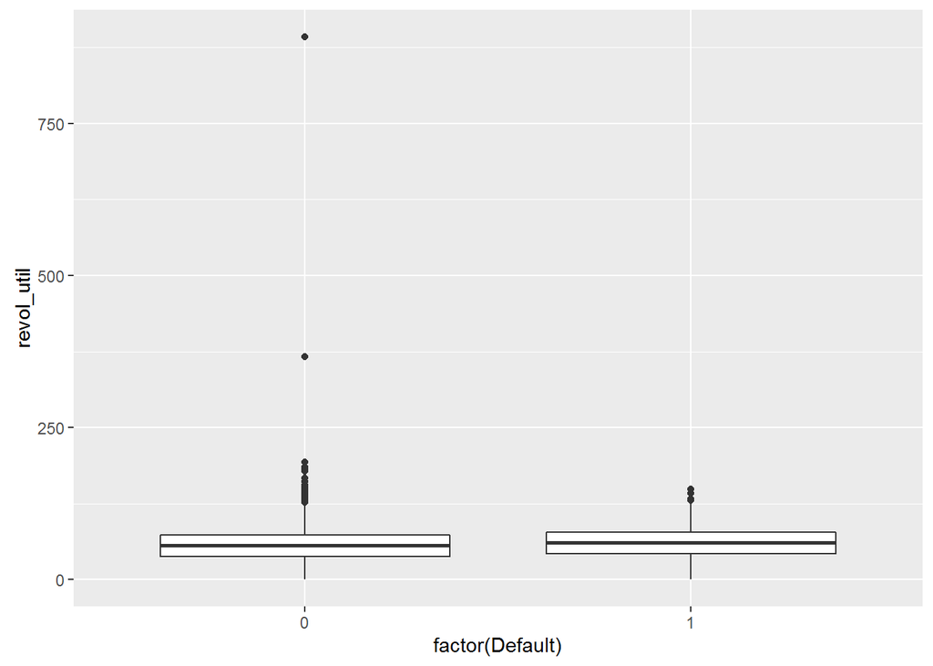

```r
p <- ggplot(train, aes(factor(Default),revol_util))
p + geom_boxplot()
```

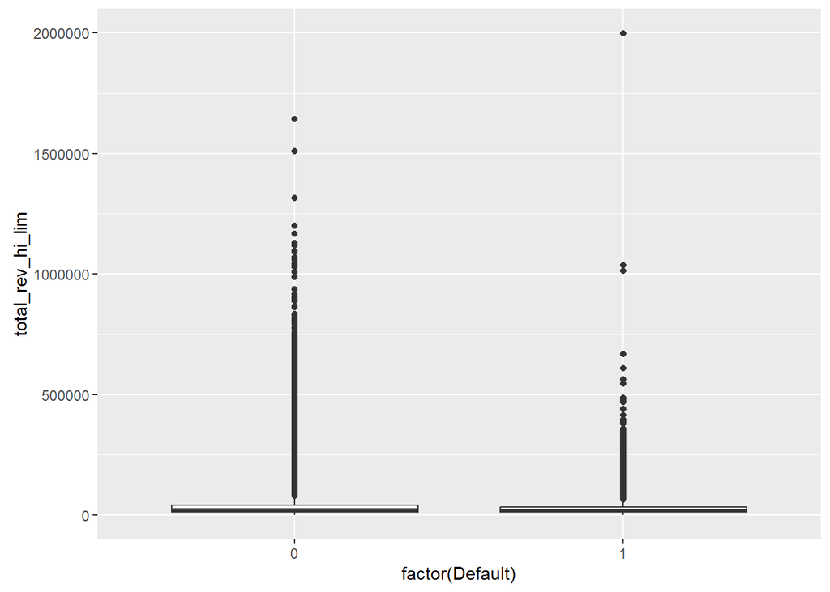

```r
p <- ggplot(train, aes(factor(Default),total_rev_hi_lim ))
p + geom_boxplot()+scale_y_continuous(limits=c(0,2000000))
```

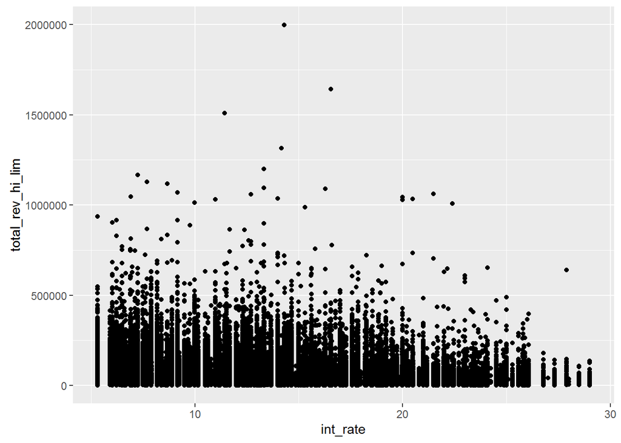

```r
p <- ggplot(train, aes(int_rate,total_rev_hi_lim ))
p +  geom_point()+scale_y_continuous(limits=c(0,2000000))
```

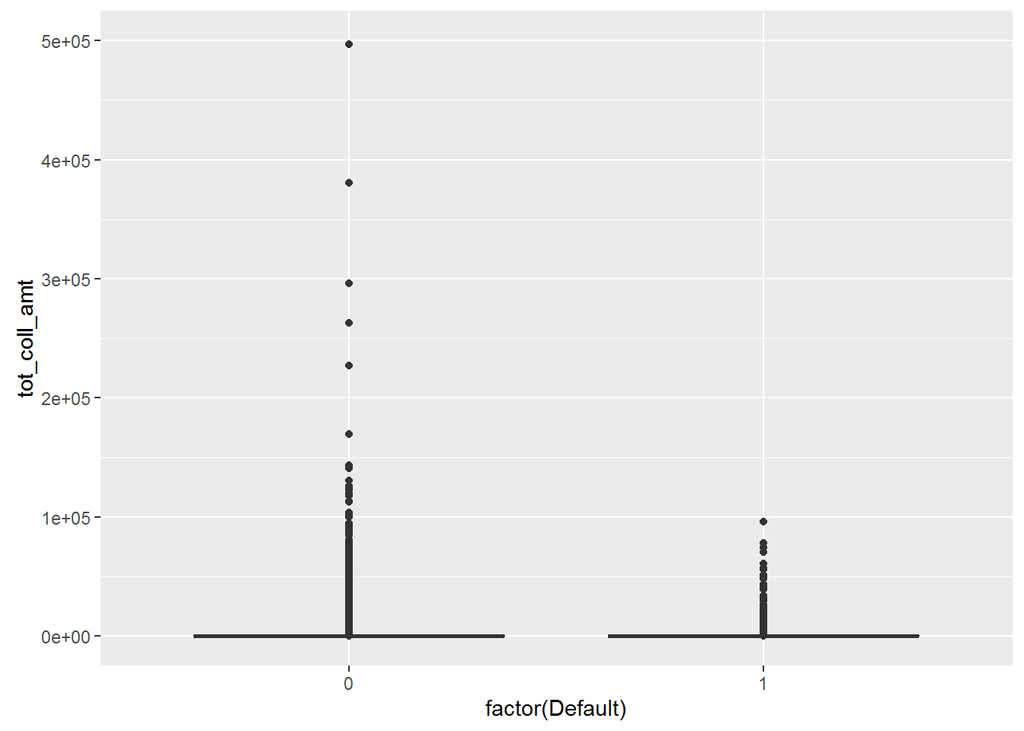

```r
p <- ggplot(train, aes(factor(Default),tot_coll_amt ))
p + geom_boxplot()+scale_y_continuous(limits=c(0,500000))
```

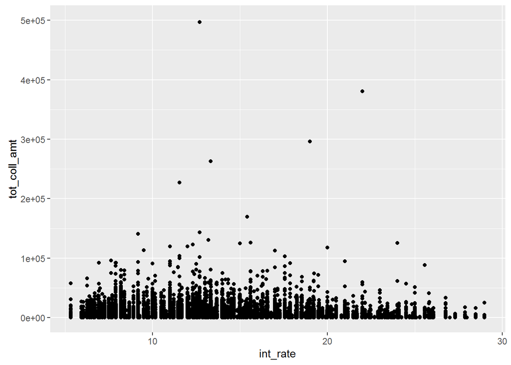

```r
p <- ggplot(train, aes(int_rate,tot_coll_amt ))
p +  geom_point()+scale_y_continuous(limits=c(0,500000))
```

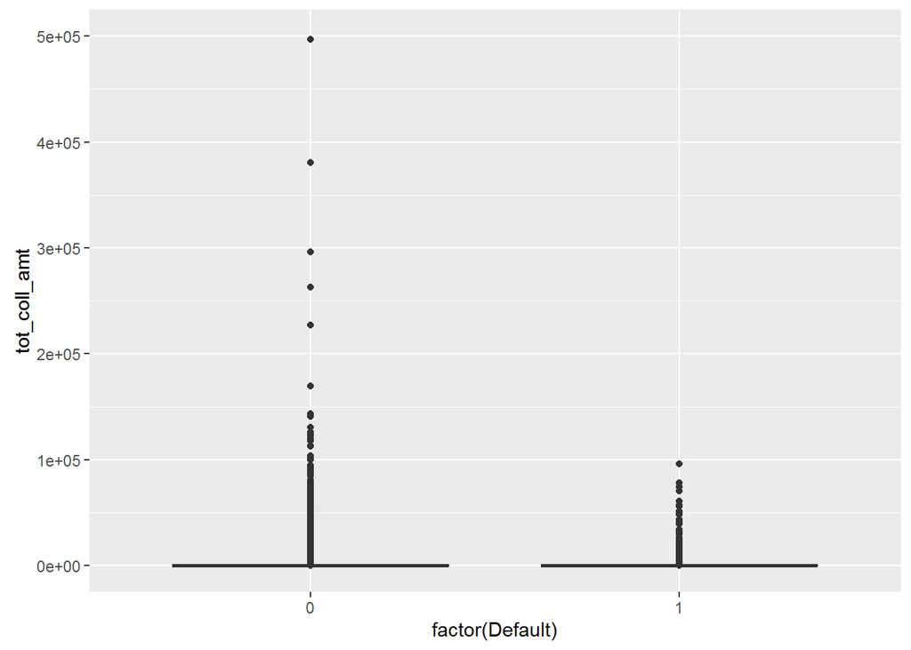

```r
p <- ggplot(train, aes(factor(Default),tot_coll_amt ))
p + geom_boxplot()+scale_y_continuous(limits=c(0,500000))
```

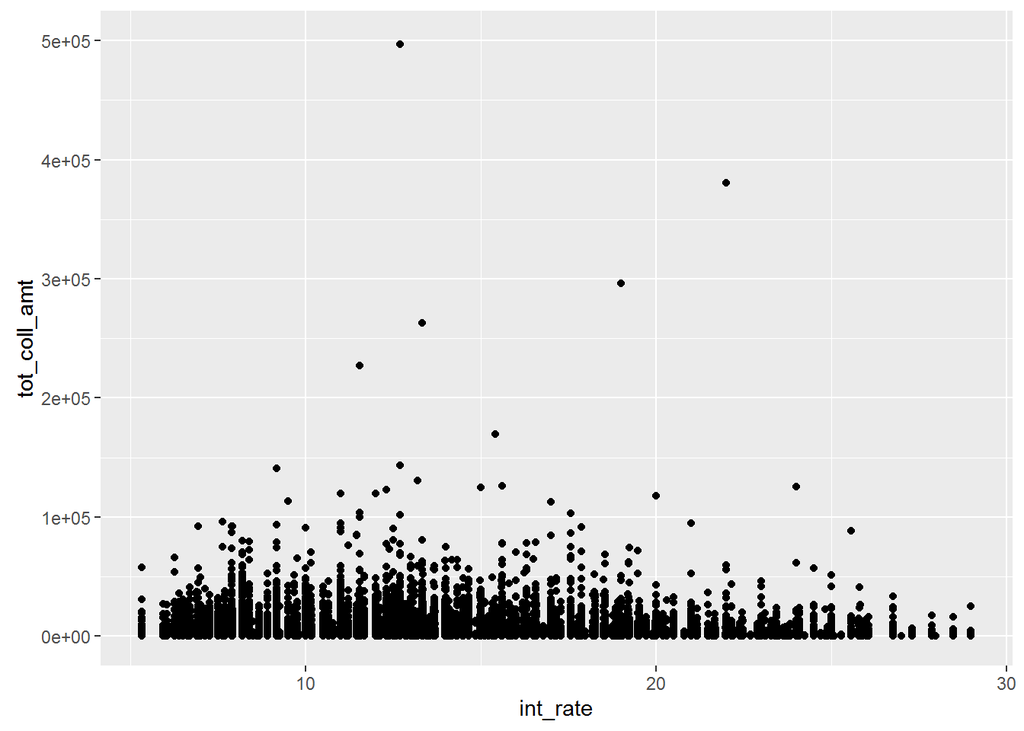

```r
p <- ggplot(train, aes(int_rate,tot_coll_amt ))
p +  geom_point()+scale_y_continuous(limits=c(0,500000))
```

On testing dependency of above categorical variables on default variable, we found that it does have a relationship except acc_now_delinq. So, We will fill null values with mean or drop those rows as they are very small in numbers in other variables and drop acc_now_delinq. Also continuous variables revol_util, total_rev_hi_lim, tot_coll_amt, tot_cur_bal can be dropped.

```r
drop<-c("revol_util", "total_rev_hi_lim", "tot_coll_amt", "tot_cur_bal","acc_now_delinq")
train<-train[,!(names(train) %in% drop)]
train<-train[!(is.na(train['open_acc']) | is.na(train['collections_12_mths_ex_med'])),]
colSums(is.na(train))
```

```
##                         id                  member_id
##                          0                          0
##                  loan_amnt                funded_amnt
##                          0                          0
##            funded_amnt_inv                       term
##                          0                          0
##                   int_rate                installment
##                          0                          0
##                      grade                  sub_grade
##                          0                          0
##                  emp_title                 emp_length
##                          0                          0
##             home_ownership                 annual_inc
##                          0                          0
##        verification_status                    issue_d
##                          0                          0
##                loan_status                 pymnt_plan
##                          0                          0
##                        url                       desc
##                          0                          0
##                    purpose                      title
##                          0                          0
##                   zip_code                 addr_state
##                          0                          0
##                        dti                delinq_2yrs
##                          0                          0
##           earliest_cr_line             inq_last_6mths
##                          0                          0
##                   open_acc                    pub_rec
##                          0                          0
##                  revol_bal                  total_acc
##                          0                          0
##        initial_list_status                  out_prncp
##                          0                          0
##              out_prncp_inv                total_pymnt
##                          0                          0
##            total_pymnt_inv            total_rec_prncp
##                          0                          0
##              total_rec_int         total_rec_late_fee
##                          0                          0
##                 recoveries    collection_recovery_fee
##                          0                          0
##               last_pymnt_d            last_pymnt_amnt
##                          0                          0
##               next_pymnt_d         last_credit_pull_d
##                          0                          0
## collections_12_mths_ex_med                policy_code
##                          0                          0
##           application_type  verification_status_joint
##                          0                          0
##                    Default
##                          0
```

Now we have cleaned data which can be used for model building. By looking the remaining features, we can find out some features which will not be necessary for model building. We need to remove them too.

```r
drop<-c("id","member_id","loan_status","issue_d","url","desc","addr_state")
train<-train[,!(names(train) %in% drop)]
```

Now we need to convert categorical variables into integers so that they can easily participate into model. First we look the types of variables in data.

```r
str(train)
```

```
## 'data.frame':    878774 obs. of  44 variables:
##  $ loan_amnt                 : num  5000 2500 2400 10000 3000 ...
##  $ funded_amnt               : num  5000 2500 2400 10000 3000 ...
##  $ funded_amnt_inv           : num  4975 2500 2400 10000 3000 ...
##  $ term                      : Factor w/ 2 levels " 36 months"," 60 months": 1 2 1 1 2 1 2 1 2 2 ...
##  $ int_rate                  : num  10.6 15.3 16 13.5 12.7 ...
##  $ installment               : num  162.9 59.8 84.3 339.3 67.8 ...
##  $ grade                     : Factor w/ 7 levels "A","B","C","D",..: 2 3 3 3 2 1 3 5 6 2 ...
##  $ sub_grade                 : Factor w/ 35 levels "A1","A2","A3",..: 7 14 15 11 10 4 15 21 27 10 ...
##  $ emp_title                 : Factor w/ 299273 levels "","'Property Manager",..: 1 224800 1 9376 282199 285977 246848 171062 1 256905 ...
##  $ emp_length                : Factor w/ 12 levels "< 1 year","1 year",..: 3 1 3 3 2 5 10 11 6 1 ...
##  $ home_ownership            : Factor w/ 6 levels "ANY","MORTGAGE",..: 6 6 6 6 6 6 6 6 5 6 ...
##  $ annual_inc                : num  24000 30000 12252 49200 80000 ...
##  $ verification_status       : Factor w/ 3 levels "Not Verified",..: 3 2 1 2 2 2 1 2 2 3 ...
##  $ pymnt_plan                : Factor w/ 2 levels "n","y": 1 1 1 1 1 1 1 1 1 1 ...
```

[output cut: 30 more lines]

```r
cat<-c("term","grade","sub_grade","emp_title","emp_length","home_ownership","verification_status"
,"pymnt_plan","purpose","title","zip_code","earliest_cr_line","initial_list_status","last_pymnt_d"
,"next_pymnt_d","last_credit_pull_d","application_type","verification_status_joint")
for (i in 1:length(cat)){
  chisq.test(table(train[,c('Default',cat[i])]))
}
```

Lets see if default cases depends on geography or not.

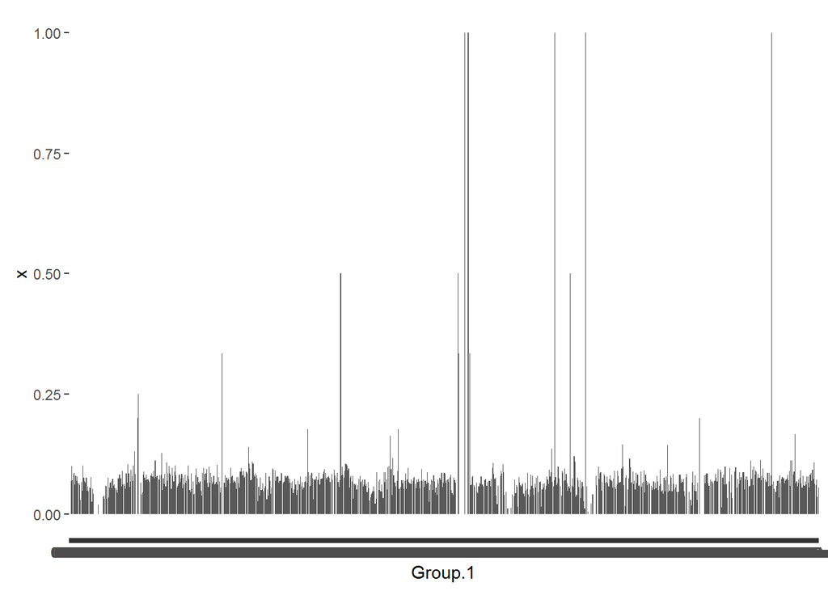

```r
df<-aggregate(train$Default, by=list(train$zip_code), FUN=mean)
df<-df[order(-df['x']),]
ggplot(df, aes(x = Group.1, y = x)) + geom_bar(stat = "identity")
```

```r
df[1:10,]
```

```
##     Group.1         x
## 494   516xx 1.0000000
## 498   524xx 1.0000000
## 606   643xx 1.0000000
## 644   682xx 1.0000000
## 876   938xx 1.0000000
## 339   353xx 0.5000000
## 485   502xx 0.5000000
## 625   663xx 0.5000000
## 191   203xx 0.3333333
## 486   503xx 0.3333333
```

```r
count(train[train["zip_code"]=='516xx',],'Default')
```

```
##   Default freq
## 1       1    1
```

```r
count(train[train["zip_code"]=='524xx',],'Default')
```

```
##   Default freq
## 1       1    1
```

```r
count(train[train["zip_code"]=='643xx',],'Default')
```

```
##   Default freq
## 1       1    1
```

```r
count(train[train["zip_code"]=='682xx',],'Default')
```

```
##   Default freq
## 1       1    1
```

```r
count(train[train["zip_code"]=='938xx',],'Default')
```

```
##   Default freq
## 1       1    1
```

```r
count(train,'verification_status_joint')
```

```
##   verification_status_joint   freq
## 1                           878327
## 2              Not Verified    254
## 3           Source Verified     51
## 4                  Verified    142
```

```r
count(train,'verification_status')
```

```
##   verification_status   freq
## 1        Not Verified 263826
## 2     Source Verified 326722
## 3            Verified 288226
```

On exploring zip codes, we found that default cases are homogeneously distributed across different geographies. So we can remove this variable from feature variables.verification_status_joint is blank for maximum observations so it also needs to be removed.

```r
drop<-c("emp_title","title","zip_code","earliest_cr_line","last_credit_pull_d","verification_status_joint",
        "last_pymnt_d","next_pymnt_d","last_credit_pull_d")
train<-train[,!(names(train) %in% drop)]
```

Now we will explore more about important remaining categorical variables. term:

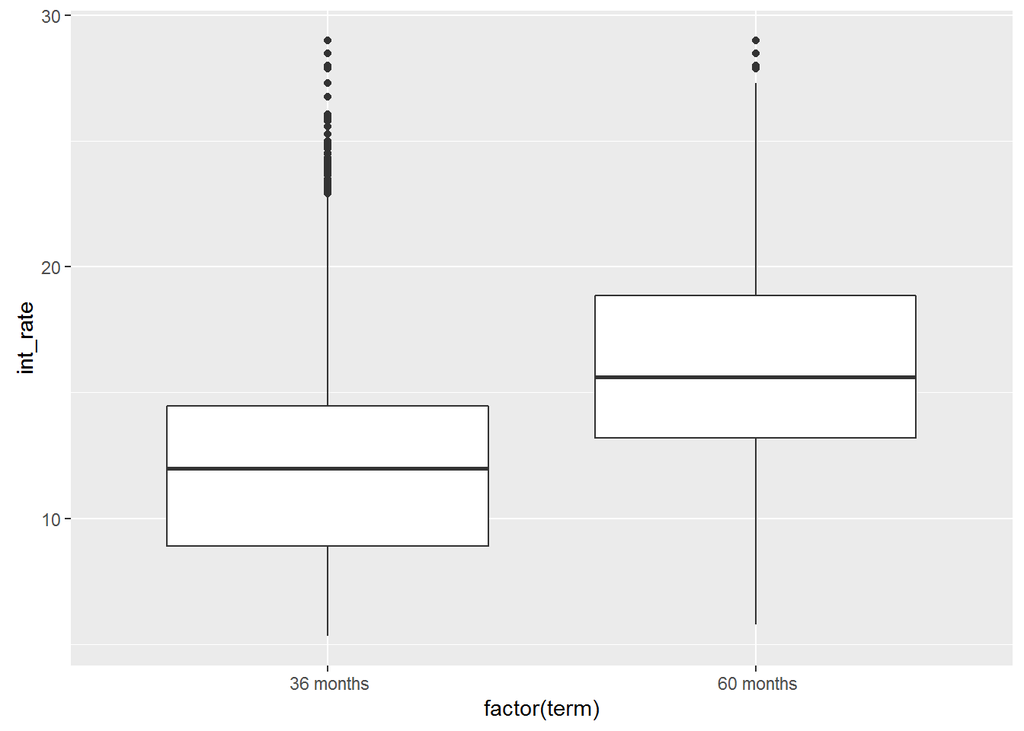

```r
ggplot(train, aes(factor(term),int_rate))+ geom_boxplot()
```

```r
aggregate(train$Default, by=list(train$term), FUN=mean)
```

```
##      Group.1          x
## 1  36 months 0.06329777
## 2  60 months 0.08423814
```

emp_length:

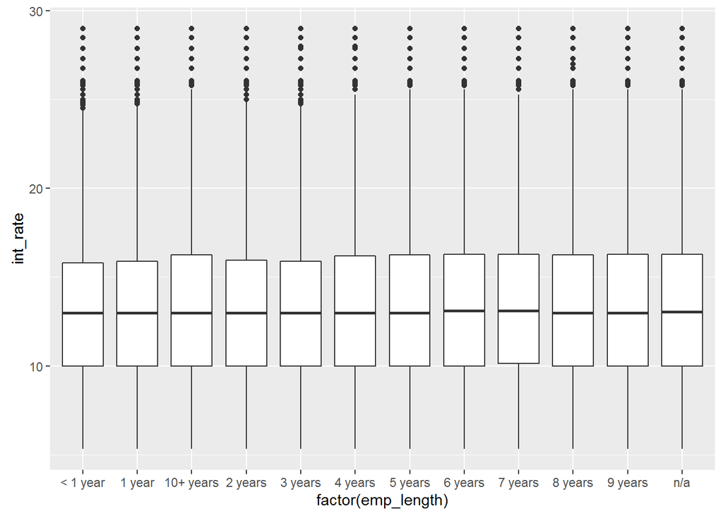

```r
ggplot(train, aes(factor(emp_length),int_rate))+ geom_boxplot()
```

```r
aggregate(train$Default, by=list(train$emp_length), FUN=mean)
```

```
##      Group.1          x
## 1   < 1 year 0.07569721
## 2     1 year 0.07204402
## 3  10+ years 0.06189998
## 4    2 years 0.06990493
## 5    3 years 0.06964937
## 6    4 years 0.07156721
## 7    5 years 0.07557529
## 8    6 years 0.08248680
## 9    7 years 0.07699944
## 10   8 years 0.06713537
## 11   9 years 0.07016880
## 12       n/a 0.07856270
```

home_ownership:

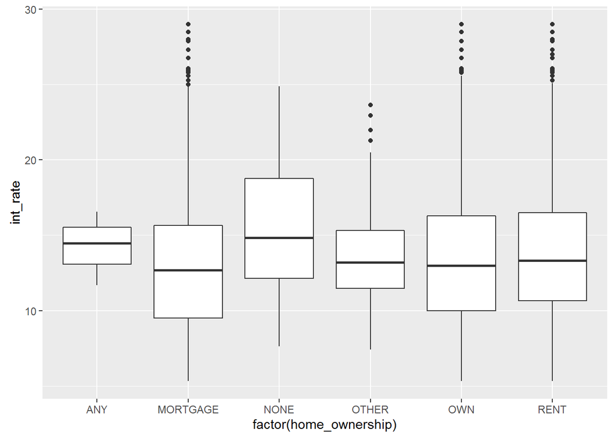

```r
ggplot(train, aes(factor(home_ownership),int_rate))+ geom_boxplot()
```

```r
aggregate(train$Default, by=list(train$home_ownership), FUN=mean)
```

```
##    Group.1          x
## 1      ANY 0.00000000
## 2 MORTGAGE 0.06107494
## 3     NONE 0.18181818
## 4    OTHER 0.20879121
## 5      OWN 0.06541386
## 6     RENT 0.08111187
```

verification_status:

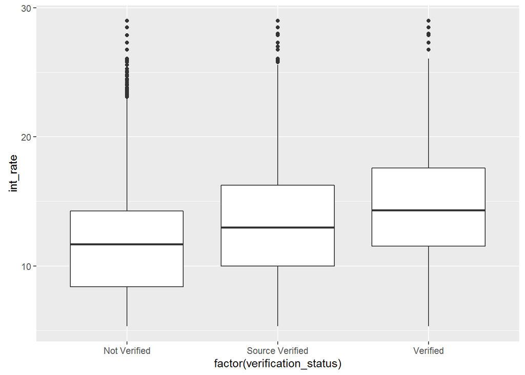

```r
ggplot(train, aes(factor(verification_status),int_rate))+ geom_boxplot()
```

```r
aggregate(train$Default, by=list(train$verification_status), FUN=mean)
```

```
##           Group.1          x
## 1    Not Verified 0.06050579
## 2 Source Verified 0.06126003
## 3        Verified 0.08732731
```

pymnt_plan:

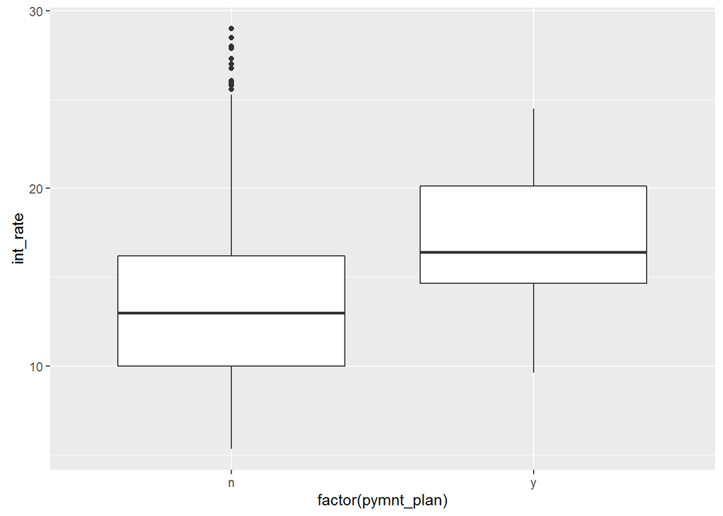

```r
ggplot(train, aes(factor(pymnt_plan),int_rate))+ geom_boxplot()
```

```r
aggregate(train$Default, by=list(train$pymnt_plan), FUN=mean)
```

```
##   Group.1          x
## 1       n 0.06957841
## 2       y 0.50000000
```

purpose:

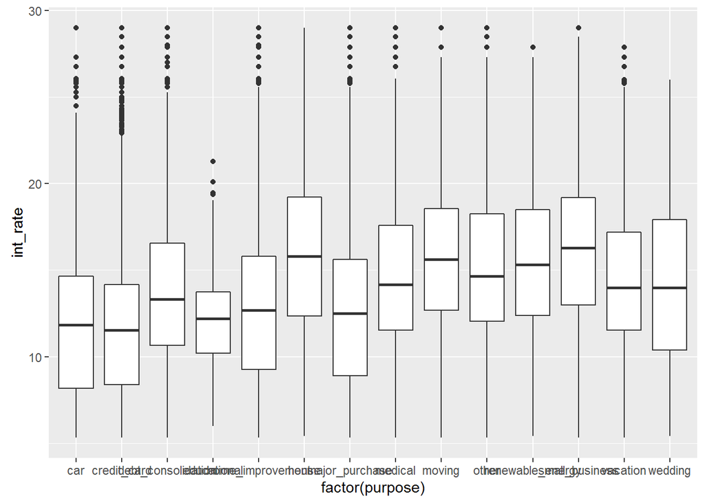

```r
ggplot(train, aes(factor(purpose),int_rate))+ geom_boxplot()
```

```r
aggregate(train$Default, by=list(train$purpose), FUN=mean)
```

```
##               Group.1          x
## 1                 car 0.06323345
## 2         credit_card 0.05193577
## 3  debt_consolidation 0.07240101
## 4         educational 0.21065375
## 5    home_improvement 0.06203484
## 6               house 0.10332606
## 7      major_purchase 0.06839057
## 8             medical 0.08853119
## 9              moving 0.10488988
## 10              other 0.09076106
## 11   renewable_energy 0.11247803
## 12     small_business 0.16580563
## 13           vacation 0.07804148
## 14            wedding 0.12148338
```

Out of above explored variables pymnt_plan and purpose of loan seem to be very important in prediction while employment years seem to be least important and hence will be removed.

```r
train$emp_length<-NULL
indx <- sapply(train, is.factor)
train[indx] <- lapply(train[indx], function(x) as.numeric(as.character(x)))
train[is.na(train)]<-0
```

Now lets see scatterplot of the data in order to discard colinear vectors from data set.

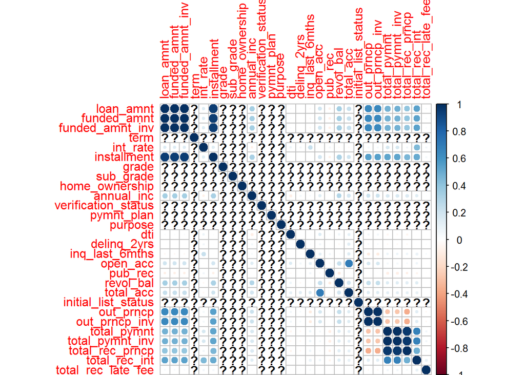

```r
library(corrplot)
corrplot(cor(train[,1:28]), method="circle")
```

```r
drop<-c("funded_amnt","funded_amnt_inv","installment","out_prncp_inv","total_rec_prncp","total_pymnt_inv")
train<-train[,!(names(train) %in% drop)]
```

```r
library("h2o")
indexes = sample(1:nrow(train), size=0.3*nrow(train))
test <- train[indexes,]
train<- train[-indexes,]
localH2O = h2o.init(max_mem_size = '6g',nthreads = -1)
```

[output not shown]

```r
train[,'Default'] = as.factor(train[,'Default'])
test[,'Default'] = as.factor(test[,'Default'])
train_h2o = as.h2o(train)
test_h2o = as.h2o(test)
rm(df,a,train.col,train.r,train1,box_status,indexes,NullValues,p,q,r,RemoveColl)
model =h2o.deeplearning(x = 1:28,  # column numbers for predictors
                     y = 29,   # column number for label
                     training_frame = train_h2o ,ignore_const_cols=FALSE# data in H2O format
                     ) # no. of epochs
```

```r
h2o.performance(model)
```

```
## H2OBinomialMetrics: deeplearning
## ** Reported on training data. **
## Description: Metrics reported on temporary training frame with 9968 samples
##
## MSE:  0.02014076
## R^2:  0.6975153
## LogLoss:  0.09402019
## AUC:  0.9381414
## Gini:  0.8762828
##
## Confusion Matrix for F1-optimal threshold:
##           0   1    Error       Rate
## 0      9241  12 0.001297   =12/9253
## 1       201 514 0.281119   =201/715
## Totals 9442 526 0.021368  =213/9968
##
## Maximum Metrics: Maximum metrics at their respective thresholds
##                       metric threshold    value idx
## 1                     max f1  0.234513 0.828364  68
## 2                     max f2  0.117794 0.771362  98
## 3               max f0point5  0.701149 0.918105  45
## 4               max accuracy  0.234513 0.978632  68
## 5              max precision  0.999999 1.000000   0
## 6                 max recall  0.000003 1.000000 399
## 7            max specificity  0.999999 1.000000   0
## 8           max absolute_MCC  0.234513 0.828214  68
## 9 max min_per_class_accuracy  0.026979 0.848951 245
##
## Gains/Lift Table: Extract with `h2o.gainsLift(<model>, <data>)` or `h2o.gainsLift(<model>, valid=<T/F>, xval=<T/F>)`
```

```r
h2o.performance(model, newdata =test_h2o)
```

```
## H2OBinomialMetrics: deeplearning
##
## MSE:  0.0195706
## R^2:  0.6971556
## LogLoss:  0.09188445
## AUC:  0.9353729
## Gini:  0.8707457
##
## Confusion Matrix for F1-optimal threshold:
##             0     1    Error          Rate
## 0      244848   476 0.001940   =476/245324
## 1        4993 13315 0.272722   =4993/18308
## Totals 249841 13791 0.020745  =5469/263632
##
## Maximum Metrics: Maximum metrics at their respective thresholds
##                       metric threshold    value idx
## 1                     max f1  0.194384 0.829621 168
## 2                     max f2  0.074594 0.773960 216
## 3               max f0point5  0.437131 0.915086 112
## 4               max accuracy  0.199130 0.979278 166
## 5              max precision  0.999995 0.997933   0
## 6                 max recall  0.000006 1.000000 399
## 7            max specificity  0.999995 0.999906   0
## 8           max absolute_MCC  0.199130 0.828317 166
## 9 max min_per_class_accuracy  0.027076 0.849754 296
##
## Gains/Lift Table: Extract with `h2o.gainsLift(<model>, <data>)` or `h2o.gainsLift(<model>, valid=<T/F>, xval=<T/F>)`
```